# In Class Exercise - Sept 26: Getting Busy with Selections

Authors

Jamaal Green

Ryan Smith

Published

September 26, 2024

*Potential skills used* *– R (**dplyr, sf)**, working with geodatabases, creating buffers*

# Introduction

This lab will cover various aspects of selections. Understanding how to grab specific kinds of data through selection techniques is one of the *essential* skills you need to do the kind of GIS planners do day in and day out. Remember, GIS is a form of *data analysis,* and, as such, we have to be able to grab meaning and information in imaginative ways. By combining attribute (table) and locational selections, we can find all kinds of new forms of knowledge and understanding that analysts who do not know GIS cannot readily imagine.

This lab will include a section that utilizes R, especially the **dplyr** and **sf** packages, alongside an ArcGIS Pro section. You may choose whichever approach or do both or a hybrid! I don’t care which one you decide to do so much as you understand the reasoning behind your steps and the functions/tools we’ll be making use of.

# The Prompt

We’ll be making use of this slightly older version of Philadelphia’s parcel map provided to you in Canvas. Throughout this lab, you will perform a series of selections to tell me the:

1. Total number of parcels
2. Total acreage of parcels
3. Average Market Value of parcels

# Selections R Style

Okay, if you have not done so yet, create a new folder and R project for it. Additionally, if it helps, create a data folder where you can place your parcel data (note that when you unzip your data you will get an additional folder, so keep this in mind for your file paths). Let’s get our packages loaded up and our data imported.

You should notice we have some new packages: **units** and **nngeo.** **units** handles, well, units of measurement in R. We will use it later. And **nngeo** is used to measure distances (**sf** has distance-related functions, but they are more complicated to use).

```r
if(!require(pacman)){install.packages("pacman"); library(pacman)}
p_load(tidyverse, sf, units, nngeo)

philly_gdb_layers <- st_layers(here::here("labs_exercises/2024-09-26_week5_AdvancedSelections/2024-09-26_In_Class_Excercise/2024-09-26_Data.gdb/"))

philly_gdb_layers
```

```
Driver: OpenFileGDB
Available layers:
  layer_name geometry_type features fields                          crs_name
1    Parcels Multi Polygon   547894    101 NAD83 / Pennsylvania South (ftUS)
2      Parks Multi Polygon      418      9 NAD83 / Pennsylvania South (ftUS)
3     Crimes            NA    13706     17                              <NA>
```

Let’s break this down. You should see something new here… `st_layers()`. Why are we using this and not `st_read()`? You’ll notice the layers in this week’s lab are in a file geodatabase! Up til now, we have read in individual shapefiles or geopackages. Remember, a geodatabase can hold multiple layers, so you cannot just read the whole thing in. We use `st_layers()` to see what layers are inside the geodatabase, and then we can call `st_read()` to bring in our layers of choice. Let’s do that now and bring in all the layers.

```r
parcels <- st_read(here::here("labs_exercises/2024-09-26_week5_AdvancedSelections/2024-09-26_In_Class_Excercise/2024-09-26_Data.gdb/"), layer = "Parcels", quiet = TRUE)

parks <- st_read(here::here("labs_exercises/2024-09-26_week5_AdvancedSelections/2024-09-26_In_Class_Excercise/2024-09-26_Data.gdb/"), layer = "Parks", quiet = TRUE)

crimes <- st_read(here::here("labs_exercises/2024-09-26_week5_AdvancedSelections/2024-09-26_In_Class_Excercise/2024-09-26_Data.gdb/"), layer = "Crimes", quiet = TRUE)
```

A quick note… depending on your folder structure, you may not need to use the **here** package. I use it because it makes everything clear to me, and when writing these labs, I want to ensure everything lines up. Remember, my file paths *will not* look like yours. Adjust accordingly.

Okay, we’ve got layers. Let’s take a look at the criteria we have to work with:

1. The owner’s first name is JOHN (note that JOHN is not the same as JOHN or JOHNSON).
2. The Sale Price (SALE_PR in our table) per Acre is greater than or equal to $500.
3. Within a distance of 500 and 1,000 feet of a park.
4. Are any type of ROW home.
5. More than 1,000 feet away from the nearest ASSAULT (i.e. any crime that has the word ASSAULT in its contents).

## Getting the Johns

Our first selection will make use of some very basic [regular expressions](https://en.wikipedia.org/wiki/Regular_expression). Regular expressions, affectionately referred to as regex, are a mysterious and dark art, so we will not go deeply into them, but we will utilize of the **stringr** package from the **tidyverse** and regex to select what we need from our text fields.

```r
johns <- parcels %>%
  filter(str_detect(string = OWNER1, pattern = "^JOHN\\s"))
```

Let’s break this down. We are subsetting rows, so we’re using `filter()`, which should be straightforward. But we see something new here: `str_detect()`. `str_detect()`is from the **stringr** package, and is used to, well, detect the presence or absence of certain string and return TRUE or FALSE if it detects that pattern. Combining this with `filter()` means that we should only return the rows where our pattern returns true. Now, let’s explore just what the heck we’re actually saying here:

1. The `str_detect()` function takes two main arguments the `string =` argument which is the column we are searching through and the `pattern =` argument which is the pattern we are searching for in the text. We are searching through the OWNER1 column as we are interested in the first owner column.
2. The pattern we search for `^JOHN\\s` is our regular expression. The ^ is a symbol for “the beginning of the string”, so the function knows to look at the beginning of the string and ignore any follow-on words.
3. The `\\s` is a special symbol unique to regex that stands for a space. Normally, you would use a single `\`, but because R will sometimes read single slashes as a file path, we use the double slash to make it clear. So `\\s` means space. So, our final regex reads as “The first word should be JOHN followed by a space”. This syntax should isolate all owners with the first name JOHN.

## Sale Price Per Acre Greater Than or Equal To $500

We do not have an “Acres” column. So, how can we solve this? We will calculate the area of our parcels in acres, then calculate our sales price per acre and filter on that.

```r
johns <- johns %>%
  mutate(parcel_acres = st_area(.)) %>%
  mutate(parcel_acres = set_units(x = parcel_acres, value = "acres"))
```

Our johns layer is projected in the Pennsylvania South State Plane projection in US feet. When we calculate the area using `st_area(.)`, it calculates the area in square feet (we use the period `.` to tell the function to reference the geometry column in the dataframe, which is basically referencing itself). Then, we follow up that by converting our area to acres using the `set_units()` function from the **units** package. You should see it in your dataframe. Okay, we are most of the way there. So, what’s next?

```r
johns <- johns %>%
  mutate(price_per_acre = as.numeric(SALE_PR/parcel_acres)) %>%
  filter(price_per_acre >= 500)
```

Let’s break it down. Calculating the price per acre is straightforward: We divide our parcel area into the sale price, but if you look at the result, you get this weird “1/acres” unit in your cell. This isn’t very helpful for us, so we can convert the column to a pure numeric one by converting it using `as.numeric()`. Finally, we continue our processing chain into a `filter()` call where we subset our rows to those parcels with a price_per_acre greater than or equal to $500.

## Within 500 and 1,000 feet of a Park- Buffer Approach

Our next step is to identify parcels that are within 500 and 1000 feet of a park. This is our first attempt at performing a selection by location. There are multiple strategies here, but we will only explore one option- a buffer approach.

The basic idea behind the buffer approach is we will draw two buffers, one of 500ft and one of 1000ft, *union* those buffers, then take the *difference* of those unioned buffers to create a ring and do our selection there. Let’s get to it:

```r
parks500 <- st_buffer(x = parks, dist = 500)

parks1000 <- st_buffer(x = parks, dist = 1000)
```

We make use of the `st_buffer()` function from **sf** here. It is fairly straightforward: We call our parks sf dataframe, and we give the distance (note the distance is in the units of your projection, in this case, feet). This quick plot shows the overlapping buffers for Clark Park. I made the 500ft buffer with a slight transparency so you can see that they do, in fact, overlap.

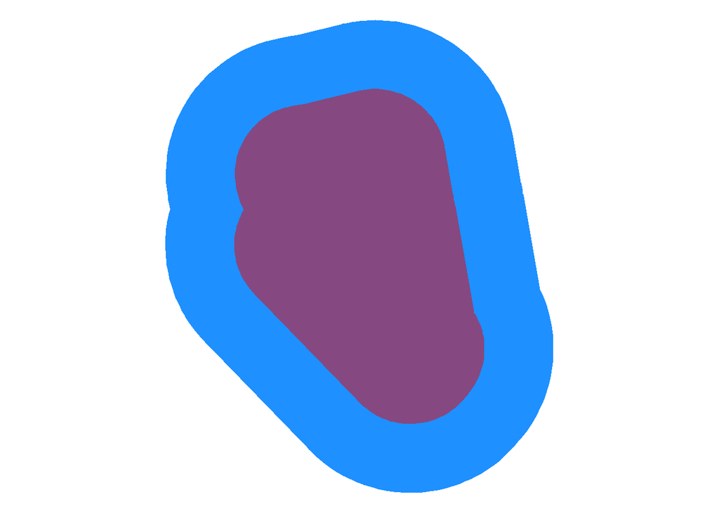

So, we have our buffers, but there’s a complication. If we were to take the difference of these buffers right now (check this section from [“Geocomputation with R”](https://r.geocompx.org/geometry-operations#geo-vec) that covers vector geometry operations, we will cover this in-depth soon), we would end up with a really large number of pieces of park buffers. This is because we have distinct parks within 1,000 feet of each other, so if we do some kind of operation, we’ll get a bunch of corner cases of intersections of buffers, and chaos will ensue. To prevent this, we will first *union* our layers, then take the difference. Let’s see it.

```r
parks500 <- st_union(parks500)
parks1000 <- st_union(parks1000)

parks_diff <- st_difference(parks1000, parks500)
```

Finally, we will take the *intersection* of the parcels with our parks_diff layer to pull out those parcels that are within the rings we just made. In order to do that, we’ll use of **sf**’s bracket notation, which is a convenient shorthand for intersections.

```r
johns <- johns[parks_diff, ]
```

## Grabbing Row Homes

The next selection is just another `filter()` using `str_detect()` again. We want to keep all parcels that begin with “ROW” in the description. This code should look familiar from earlier:

```r
johns <- johns %>%
  filter(str_detect(string = DESC, pattern = "^ROW"))
```

## Isolating Assaults

The next steps involve identifying assaults from our crimes dataframe and selecting parcels that are more than 1,000 feet away. The steps:

1. Convert crimes to points.
2. Isolate assaults.
3. Draw buffers on our points.
4. Use `st_intersects()` to create a logical vector of whether our parcels intersect the crime buffers.
5. Select the parcels that do *not* intersect the buffer.

Take your time with these steps. There will be a couple of things here that do not make immediate sense, but if you walk through it and take time with the syntax. I think the underlying logic will make sense.

```r
crimes <- crimes %>%
  filter(!is.na(lng) | !is.na(lat)) %>%
  st_as_sf(coords = c("lng", "lat"), crs = 4326) %>%
  st_transform(st_crs(johns))
```

Let’s walk through this. We take our crimes dataframe and pipe into a `filter()` where we see something a little different. In order to convert the dataframe to a simple features dataframe, we cannot have any empty geometries, so, in this case, that means we cannot have any missing coordinates. So, I use `!is.na(lng) | !is.na(lat)`. What this means is I want rows that are *not* `NA` for either lng OR lat. the `|` is shorthand for the OR operator.

Next, we feed our dataframe into `st_as_sf()`, give the coordinates, and set the projection to WGS84, and, finally, we transform the projection of the crime points to the same projection as our parcels. Take a little time here and make sure you understand what we’re doing here.

The next steps will look a little weird, but we will go over the logic step-by-step. First, we will get the *intersection* of the buffered crimes and our parcels using `st_intersects()`. `st_intersects()` will return an object called a “sparse geometry binary predicate list”, and more detail can be found in [“Geocomputation with R”](https://r.geocompx.org/spatial-operations#spatial-vec). The basic definition of this object is it returns a list of 0s and 1s that represent whether a feature in a layer intersects with another. We can then use this list to subset our layer of interest. This all sounds confusing, so let’s take a look.

```r
crime_parcels <- st_intersects(johns, crimes1000)
```

[output not shown]

If you click on the parcel crimes object in your environment, you should notice it is a list that is the same length as our johns dataframe. If you look inside, you will see for each element of our list, there are either multiple numbers or a 0. Those numbers represent the index values of the buffers that a particular point intersects, and where you see a 0, that shows that a particular parcel does not intersect with any buffers.

- Do not think too hard about this just yet…look at it, absorb it, and read the section in “Geocomputation with R” if you’d like. But the basic idea is now we have a list that tells us whether our parcels intersect with any buffers.

Next, we will select only those elements in our list that have zeroes (remember, 0 here means no intersection). To do so, we will return the elements of our list where the *length* of the elements is 0. Let’s take a look.

```r
crime_logical <- lengths(crime_parcels) == 0
```

And now, finally, we will subset our johns dataframe to get our final parcels.

```r
final_parcels <- johns[crime_logical, ]
```

And that’s it! Let’s take a look at where we should end up.

- The final number of parcels- 49.
- Total Acreage- 2.54.

Average Market Value (MV)- $164,663.30.

# Selections ArcGIS Style

- The owner’s first name is JOHN (note that JOHN is not the same as JOHNS OR JOHNSON)
- The Sale Price (SALE_PR) per Acre (note “Acres” doesn’t exist yet; you’ll have to create and calculate this field) is greater than or equal to $500
- Are within 500 and 1,000 feet of a park (can also be thought of as greater than 500 feet from a park but less than 1,000 feet away from a park)
- Is any type of ROW home (i.e. beginning with ROW in the DESC field)
- Are more than 1,000 feet away from the nearest Assault (i.e. any kind of crime that has the word Assault in its contents. Note that you’ll also need to map crimes before you can achieve this).

**Advanced Topic:** The advanced topic tonight is to try and accomplish the selections correctly WITHOUT using the detailed steps below:

## Steps

**1: The Owner’s Name is JOHN…**

- This is a good example of a “Begins With” search in Select by Attributes.
- In Select by Attribute, create a new Query. You are looking for the following:
- Where OWNER1 begins with JOHN.
- NOW, I want you to try this in two ways: If you type JOHN and then hit run – note the number. Now type JOHN and a [SPACE] after the N (effectively “JOHN”). Notice how the count changes! This is because the second option (which is the **correct one**) is searching for instances of “JOHN”, or Owners that have the letters JOHN then a space (i.e. JOHN as the first name).

**INTERMEDIATE STEP THAT YOU WILL REPEAT OVER AND OVER**

- Remember that the request asks for parcels that meet **all of the criteria.** This means you need to preserve the results from each previous selection. You can do this in one of two ways:
  - You can just keep using “Select Subset From Current Selection” from the Selection Type in both Select by Attributes and Location.
  - After each step, right-click the parcels layer, and under the selection dropdown, pick “Make Layer from Selected Feature.” This will create a layer of ONLY selected items. Then, you will perform the next selection step on this layer.

**2: Sales Price Per Acre >= $500**

- Remember to make this selection on the parcels that remain after the previous step.
- There is no “Acres” field (and therefore no “Price Per Acre” field as a result). You’ll need to create these first.
- For Acres – create a new field called Acres and make it a Double. Right-click this field and select Calculate Geometry – select Acres.
- Create a new field called “PPA” (or something equivalent to mean price per acre). Make this a Double.
- Right-click this field and pick Calculate Field. Set up a calculation that is !SALE_PR! / !ACRES!
- Now you can use Select by Attributes to set up a new Query that is:
  - Where PPA is greater than or equal to 500.
- Make sure to set up your preferred intermediate step.

**4: Is Any Type of Row Home**

- Remember to make this selection only on the parcels that remain after the previous step.
- This step is fairly similar to step one. In Select by Attribute just use the following expression:
  - Where DESC begins with ROW.
- Make sure to set up your preferred intermediate step.

**5: More than 1,000 Feet from Any Assault**

- Remember to make this selection only on the parcels that remain after the previous step.
- This final selection will require you to combine a Select by Location with a Select by Attribute. But first, you’ll need to map crimes!
- Take the crimes.dbf and plot the XY Coordinates.
- Once crimes are plotted, open the attribute table for the shapefile and examine the “text_general_field” attribute. Browse some records and see that the word Assault (spelled just like that) appears within the middle of several records. So our previous selection “begins with” won’t work.
- Open Select by Attributes. Set up the following expression:
  - Where text_general_field – “contains the text” – Assault.
- When you hit run, this will find any record that has the word “Assault” in it. If you’ve done this right, it will be 2,466 selections.
- You can either: A) Just leave the Selection alone; B) Make a Layer from Selected Feature. Either will work for the next step.
- Now open Select by Location. Make sure the input feature is the most current iteration of the parcels selection. For relationship, choose within a distance of and enter 1,000 feet. Make the selecting features the Selected Crime Layer (i.e., the crimes with assaults selected). *Before you hit run – pause and reflect on what it will give you.* This would be close, but not quite correct. This would give you anything within 1,000 feet – but you want beyond 1,000 feet. The fix is very easy. Run the selection, then open the attribute table and select the “Switch Selection” icon at the top of the attribute table. This will reverse the previous selection and give you the final number of parcels!
- Now click run!

**6: Calculate Total Acres and Average Market Value**

- For the final step, you’ll need to use statistics. Right-click on both the Acres and the Market Value (MV) fields and select statistics. Navigate the responding windows to see sums and averages for these fields.

# To Turn In

- Create a document (PPT, PDF, Word…) that accomplishes three things:
  - Present the answers to the three questions (# of parcels; total acres; average market value)
  - Walk through the process. What made sense? What seemed particularly confusing or clarifying?
- Design a map that symbolizes the selected parcels among the rest of the parcels in the city. Be sure to include the appropriate map elements.

Please turn this in before 11:59 pm on Thursday, October 10th.